# Fault prediction in semi-conductor manufacturing process

Menasria Hafidh

13 février 2018

# Introduction

A complex modern **semi-conductor manufacturing process** is normally under consistent surveillance via the monitoring of signals/variables collected from sensors and or process measurement points. The datesets are donated in *2008-11-19* and can be obtained from http://archive.ics.uci.edu/ml/machine-learning-databases/secom/. Data descreption: it consists of two files one is *secom.csv* and *secom_labels.csv*.

- *1567* data points or measurements.
- *590* variabels, one label *1* for fail and *-1* for pass and variable for the time points beimg measured.

Analysis process:

- Reduce the number of features and obtain the most relevent variables that affect the fault.
- Develope a *classification model* to detect that occurance of a *faul*.
- Develope another *classification model* to *predict* the *fault* within **1 hour**.

# Preparation

## Loading packages

```r
library(caret) #model building
library(ggcorrplot) #visualisation
library(FSelector)  #feature selection
library(kernlab)
library(gbm)
```

## Loading data

```r
setwd("E:/Data analysis/FYP/project")
labels <- read.table("secom_labels.data",dec = " ")
data <- read.table("secom.data",dec = " ",sep = " ")
```

## shift function

The shift function is used to create *lagged* input features since we are dealing with *time series signal*

```r
shift<-function(x,shift_by){
  stopifnot(is.numeric(x))
  stopifnot(is.numeric(shift_by))
  if(length(shift_by)>1)
    sapply(shift_by,x=x,shift)
  shift_by_abs <- abs(shift_by)

    if (shift_by>0)
      out <- c(tail(x,-shift_by_abs),rep(NA,shift_by_abs))
    else if(shift_by<0)
      out <- c(rep(NA,shift_by_abs),head(x,-shift_by_abs))
  else
    out <- x
  out
}
```

## fault_time function

this function is used to add another outcom variable that tells wether a fault will happen after a sertain time

```r
fault_time <- function(x,time){

  v <- 0

  n <- nrow(x)
  for(i in 1:(n-10)){
    bool <- FALSE
      for(j in (i+1):(i+10)){

    m <-  (as.numeric(x$V2[j]) - as.numeric(labels$V2[i]))/60
    if(x[j,1] > 0)
      bool <- TRUE

          if(m>time ){
      if(bool)
        v[i] <- 1
      else
        v[i] <- -1
      break()
        }
    }
  }
  v <- c(v,rep(NA,10))
  return(v)
}
```

# Data cleaning

Removing variables with *missing* values and near-zero-variance

## missing values

```r
dim(data)
```

```
## [1] 1567  590
```

```r
missing <- sapply(data,function(x) any(is.na(x)))
sum(missing)
```

```
## [1] 124
```

```r
names <- names(missing[!missing])
data_no_m <- data[,names]
dim(data_no_m)
```

```
## [1] 1567  466
```

the data contains *124* with missing values.

## near zero variance

variables that does not vary too much or have single values are removed

```r
nzv <- nearZeroVar(data_no_m,saveMetrics = T)
names <- row.names(nzv[!nzv$nzv,])
data_no_nzv <- data_no_m[,names]
dim(data_no_nzv)
```

```
## [1] 1567  457
```

*9* columns with **near-zero-variance** are removed.

## Converting data into numerical

```r
data_numeric <- sapply(data_no_nzv,function(x){x<-as.numeric(x)})
data_numeric <- data.frame(data_numeric)
head(str(data_numeric),10)
```

```
## 'data.frame':    1567 obs. of  457 variables:
##  $ V1  : num  910 1372 175 557 922 ...
##  $ V2  : num  1267 471 1245 580 798 ...
##  $ V3  : num  162 438 154 240 448 448 438 479 479 479 ...
##  $ V4  : num  238 266 345 469 216 216 266 2 2 2 ...
##  $ V5  : num  281 39 369 249 383 383 39 18 18 18 ...
##  $ V7  : num  437 97 387 174 16 16 97 241 241 241 ...
##  $ V8  : num  64 69 63 39 57 57 69 9 9 9 ...
##  $ V9  : num  812 795 502 750 823 ...
##  $ V10 : num  440 5 324 122 31 444 236 435 391 437 ...
##  $ V11 : num  34 141 212 33 72 254 304 206 66 248 ...
##  $ V12 : num  30 190 178 192 134 262 155 50 63 19 ...
##  $ V13 : num  1239 969 1162 1121 1145 ...
##  $ V15 : num  1117 25 1452 1475 117 ...
##  $ V16 : num  953 945 1055 1337 1264 ...
```

[output cut: 86 more lines]

## Generating lagged input features

generating *t-1*,..,*t-5* of all variables as lagged inputs

```r
data_lag <- data_numeric
names <- names(data_numeric)

for(i in 1:5){
     for(j in 1:length(data_numeric)){
       name <- paste(names[j],"lag",i,sep = "_")
       names <- c(names,name)
       data_lag$name <- shift(data_numeric[,j],-i)
       names(data_lag) <- names
     }
}
data_lag <- na.omit(data_lag)
dim(data_lag)
```

```
## [1] 1562 2742
```

## Add predicted fault as a label

```r
labels$V2 <- as.POSIXlt(as.character(labels$V2), format="%d/%m/%Y %H:%M:%S")
labels$v1_1_hour <-fault_time(labels,60)
labels <- na.omit(labels)
data_lag <- data_lag[1:(nrow(data_lag)-10),]
labels  <- labels[-c(1:5),]
```

## Generate min, hour, day and month features

```r
labels$min <- labels$V2$min
labels$hour <- labels$V2$hour
labels$day <- labels$V2$mday
labels$month <- labels$V2$mon
```

# Data reduction

## Correlation

variables that are highly correlated to each other are selected and removed using the caret package.

```r
preProces <- preProcess(data_lag,method = "corr",cutoff = 0.75)
data_lag_nzc <- predict(preProces,newdata = data_lag)
dim(data_lag_nzc)
```

```
## [1] 1552 1770
```

## chi-square test

Use of chi-square test to calculate variable importance after balancing the data with respect to the class.

```r
data <- data_lag_nzc
data$class <- as.factor(labels$V1)
data <- upSample( x = data[,-ncol(data)],y = data$class)
table(data$Class)
```

```
##
##   -1    1
## 1449 1449
```

```r
weights<- chi.squared(Class~., data)
subset <- cutoff.k(weights,800) ## 400
subset <- c(subset,"Class")
data <- data[,subset]
```

selecting 800 variables.

## Variable importance using gbm model

build a gbm model and calculating variable importance.

```r
set.seed(0)
intrain <- createDataPartition(data$Class,p=0.7,list = F)
train <- data[intrain,]
test <- data[-intrain,]
gbmCntrl <- trainControl(method = "cv",number = 10,verboseIter=FALSE)
gbmFit   <- train(Class~.,data=train,method = "gbm",trControl = gbmCntrl,verbose = FALSE)
p <- predict(gbmFit,newdata = test)
confusionMatrix(p,test$Class)
```

```
## Confusion Matrix and Statistics
##
##           Reference
## Prediction  -1   1
##         -1 419   0
##         1   15 434
##
##                Accuracy : 0.9827
##                  95% CI : (0.9717, 0.9903)
##     No Information Rate : 0.5
##     P-Value [Acc > NIR] : < 2.2e-16
##
##                   Kappa : 0.9654
##  Mcnemar's Test P-Value : 0.0003006
##
##             Sensitivity : 0.9654
##             Specificity : 1.0000
##          Pos Pred Value : 1.0000
##          Neg Pred Value : 0.9666
##              Prevalence : 0.5000
##          Detection Rate : 0.4827
##    Detection Prevalence : 0.4827
##       Balanced Accuracy : 0.9827
##
##        'Positive' Class : -1
##
```

```r
vImp <- varImp(gbmFit,numTrees =150)
variables <- names(train[,-length(train)])
variables <- variables[which(vImp$importance>0)]
data <- data_lag_nzc[,c(variables)]
length(variables)
```

```
## [1] 248
```

## Principal component analysis

PCA is used to get projected data with the most variance retained as a dimensionality reduction process.

```r
preP <- preProcess(data,method = "pca",pcaComp = 60)
pc <- predict(preP,newdata = data)
length(pc)
```

```
## [1] 60
```

data has been reduced to *60*

## Add time and lagged fault to data

```r
pc$min <- labels$min
pc$hour <- labels$hour
pc$day <- labels$day
pc$month <- labels$month
```

# Model building

## Detect fault

ensembling method will be used, combining classifiers by voting to improve accuracy

```r
ensamble <- function(){
trContrl = trainControl(method="cv",number=3,verboseIter=FALSE)
svm.fit <- train(Class ~.,method="svmRadial",data=training,trControl=trContrl)
nnet.fit <- train(Class ~.,method="nnet",data=training,trControl=trContrl,verbose= FALSE)
knn.fit <- train(Class ~.,method="knn",data=training,trControl=trContrl)
rf.fit <- train(Class ~.,method="rf",data=training,trControl=trContrl)
xgboost.fit <- train(Class ~.,method="xgbTree",data=training,trControl=trContrl)
glm.fit <- train(Class ~.,method="glm",data=training,trControl=trContrl)



svm.pred.test <- predict(svm.fit,testing)
nnet.pred.test <- predict(nnet.fit,testing)
xgboost.pred.test <- predict(xgboost.fit,testing)
knn.pred.test <- predict(knn.fit,testing)
glm.pred.test <- predict(glm.fit,testing)
rf.pred.test <- predict(rf.fit,testing)
resamps <<- resamples(list(GLM = glm.fit,
                          SVM = svm.fit,
                          NNET = nnet.fit,
                          KNN = knn.fit,
                          XGB = xgboost.fit,
                          RF  = rf.fit))
theme1 <- trellis.par.get()
theme1$plot.symbol$col = rgb(.2, .2, .2, .4)
theme1$plot.symbol$pch = 16
theme1$plot.line$col = rgb(1, 0, 0, .7)
theme1$plot.line$lwd <- 2
trellis.par.set(theme1)
print(bwplot(resamps, layout = c(3, 1)))
trellis.par.set(caretTheme())


confusionMatrix(xgboost.pred.test,testing$Class)

combinedTestData <- data.frame(svm.pred=svm.pred.test,
nnet.pred = nnet.pred.test,xgboost.pred=xgboost.pred.test,knn.pred=knn.pred.test,glm.pred = glm.pred.test,rf.pred = rf.pred.test,Class=testing$Class)

comb.fit <- train(Class ~.,method="gbm",data=combinedTestData,trControl = trainControl(method = "cv",number = 3,verboseIter=FALSE),verbose = FALSE)
# use the resultant model to predict on the test set
comb.pred.test <- predict(comb.fit, combinedTestData)
# use the glm and rf models to predict results on the validation data set

svm.pred.val <- predict(svm.fit,validation)
nnet.pred.val <- predict(nnet.fit,validation)
xgboost.pred.val <- predict(xgboost.fit,validation)
knn.pred.val <- predict(knn.fit,validation)
glm.pred.val <- predict(glm.fit,validation)
rf.pred.val <- predict(rf.fit,validation)# combine the results into data frame for the comb.fit
combinedValData <- data.frame(svm.pred=svm.pred.val,
nnet.pred = nnet.pred.val,xgboost.pred=xgboost.pred.val,knn.pred=knn.pred.val,glm.pred = glm.pred.val,rf.pred = rf.pred.val,Class=validation$Class)
# run the comb.fit on the combined validation data
comb.pred.val <- predict(comb.fit,combinedValData)
print(confusionMatrix(comb.pred.val,validation$Class))
}
```

## detect faults

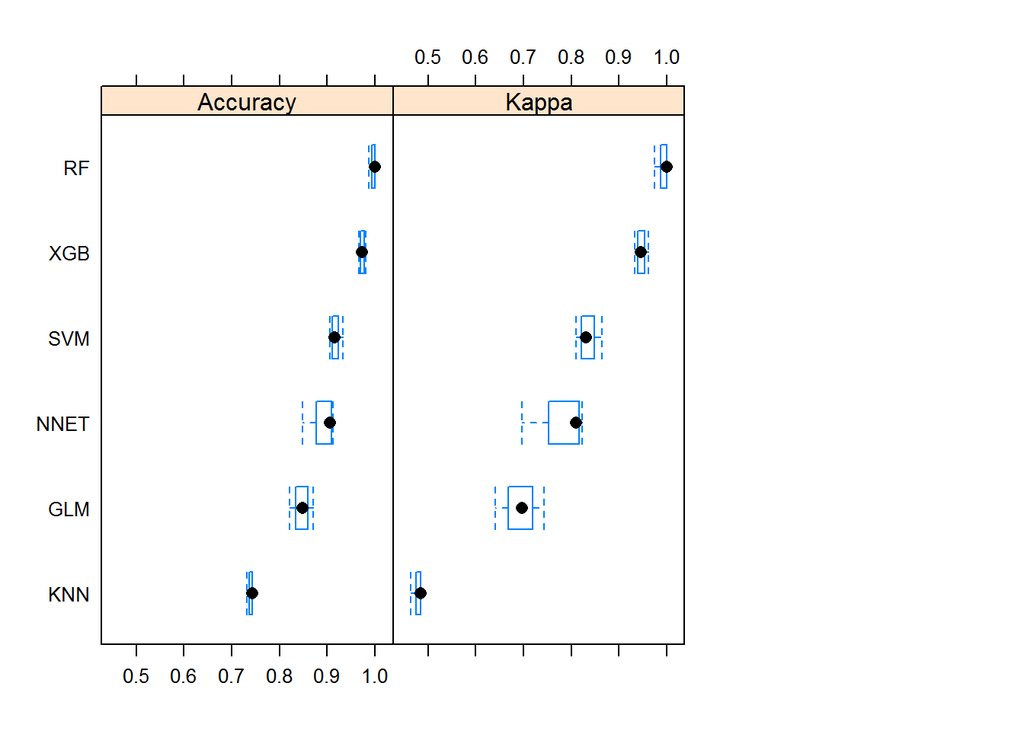

```
## Confusion Matrix and Statistics
##
##           Reference
## Prediction  -1   1
##         -1 434   0
##         1    0 434
##
##                Accuracy : 1
##                  95% CI : (0.9958, 1)
##     No Information Rate : 0.5
##     P-Value [Acc > NIR] : < 2.2e-16
##
##                   Kappa : 1
##  Mcnemar's Test P-Value : NA
##
##             Sensitivity : 1.0
##             Specificity : 1.0
##          Pos Pred Value : 1.0
##          Neg Pred Value : 1.0
##              Prevalence : 0.5
##          Detection Rate : 0.5
##    Detection Prevalence : 0.5
##       Balanced Accuracy : 1.0
##
##        'Positive' Class : -1
##
```

```r
pc1 <- pc
pc$out <- as.factor(labels$V1)
pc <- upSample( x = pc[,-ncol(pc)],y = pc$out)
intrain <- createDataPartition(pc$Class,p=0.7,list = F)
buildData <- pc[intrain,]
validation <- pc[-intrain,]
inTrain <- createDataPartition(y=buildData$Class,p=0.7, list=FALSE)
training <- buildData[inTrain,]; testing <- buildData[-inTrain,]
ensamble()
```

## predict faults with in an hour

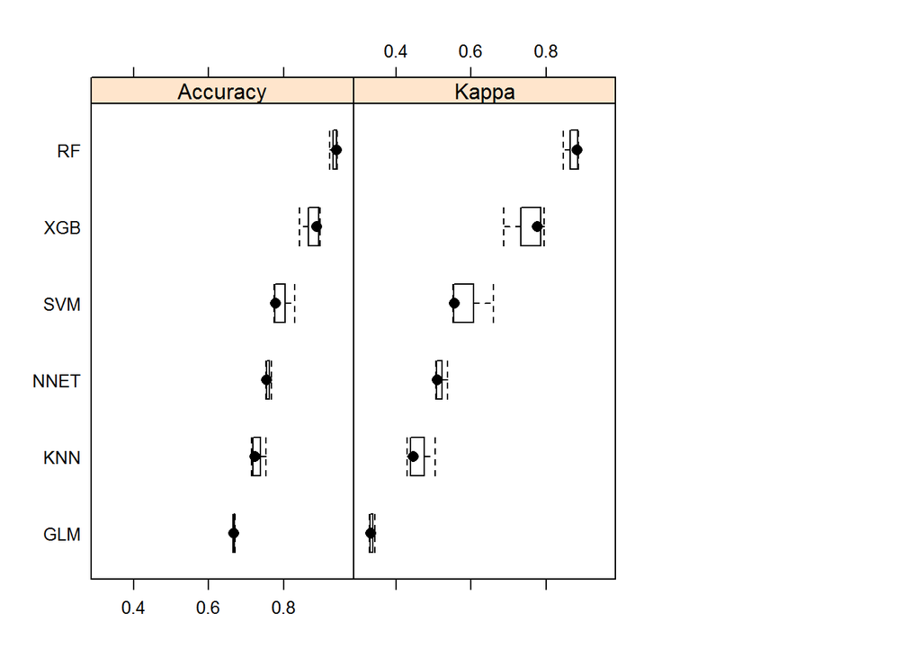

```
## Confusion Matrix and Statistics
##
##           Reference
## Prediction  -1   1
##         -1 404   5
##         1    0 399
##
##                Accuracy : 0.9938
##                  95% CI : (0.9856, 0.998)
##     No Information Rate : 0.5
##     P-Value [Acc > NIR] : < 2e-16
##
##                   Kappa : 0.9876
##  Mcnemar's Test P-Value : 0.07364
##
##             Sensitivity : 1.0000
##             Specificity : 0.9876
##          Pos Pred Value : 0.9878
##          Neg Pred Value : 1.0000
##              Prevalence : 0.5000
##          Detection Rate : 0.5000
##    Detection Prevalence : 0.5062
##       Balanced Accuracy : 0.9938
##
##        'Positive' Class : -1
##
```

```r
pc <- pc1
pc$out <- as.factor(labels$v1_1_hour)
pc <- upSample( x = pc[,-ncol(pc)],y = pc$out)
intrain <- createDataPartition(pc$Class,p=0.7,list = F)
buildData <- pc[intrain,]
validation <- pc[-intrain,]
inTrain <- createDataPartition(y=buildData$Class,p=0.7, list=FALSE)
training <- buildData[inTrain,]; testing <- buildData[-inTrain,]
ensamble()
```